# University Clustering

Jack Hopper

12/4/2023

## Introduction - Why Do This Analysis?

One of the most interesting Unsupervised Machine Learning techniques is clustering. Clustering helps us find interesting ways to group items based on how similar they are. One useful application of clustering is in higher education. For example, consider two schools in my home state of Ohio. Should we think of the College of Wooster as a comparable school to the University of Dayton? Both are private colleges that enroll less than 10,000 students, have a healthy share of out-of-state students, and charge relatively high (>$40,000) tuition. When we’re classifying universities, should they be in the same group?

For this analysis, I’ll attempt to classify schools based on their selectivity. ‘Selectivity’ is a vague metric, but there are a handful of meaningful statistics that represent selectivity based on university prestige and academic rigor. These are metrics such as tuition rates, admission rates, ACT scores for incoming students, and total enrollment.

### Data Gathering & Exploration

IPEDS publishes a Microsoft Access database every year with hundreds of variables covering thousands of higher education institutions. To simplify things, I exported the relevant tables from Access to Excel, to streamline the analysis & move away from the bulky Access database.

For this analysis, we need the tidyverse as well as the readxl package to load the Excel data.

```r
# Read data
institution <- read_excel("data\\HD2021.xlsx")
adm <- read_excel("data\\ADM2021.xlsx")
adm_yield <- read_excel("data\\DRVADM2021.xlsx")
enrollment <- read_excel("data\\DRVEF2021.xlsx")
enrollment_d <- read_excel("data\\EF2021D.xlsx")
tuition <- read_excel("data\\IC2021_AY.xlsx")
```

##### Build the data frame

We will require data on multiple categories. Note that IPEDS stores each variable with a mnemonic - so note that I have taken steps to translate each mnemonic into a more informative variable name.

```r
#Institutional characteristics

institution <- institution %>%
  select(UNITID, INSTNM, ICLEVEL, CONTROL,  LATITUDE, LONGITUD, ADDR, CITY, STABBR, ZIP, CBSA) %>%
  rename(school = INSTNM)

#Admissions
adm <- adm %>%
  select(UNITID, ACTCM75) %>%
  rename(act_score = ACTCM75
         )
#DRAdmissions table
adm_yield <- adm_yield %>%
  select(UNITID, DVADM01) %>%
  rename(pct_admitted = DVADM01)

#Enrollment characteristics
enrollment <- enrollment %>%
  select(UNITID, EFUG, EFUGFT, EFUGPT, PCUDEEXC, RMINSTTP, RMOUSTTP, RMFRGNCP) %>%
  rename(ug_enroll = EFUG,
         ft_enroll = EFUGFT,
         pt_enroll = EFUGPT,
         pct_online = PCUDEEXC,
         pct_instate = RMINSTTP,
         pct_outstate = RMOUSTTP,
         pct_foreign = RMFRGNCP)
enrollment_d <- enrollment_d %>%
  select(UNITID, RET_PCF) %>%
  rename(retention_rate = RET_PCF)
enrollment <- left_join(enrollment, enrollment_d, by = c("UNITID" = "UNITID"))

#Tuition
tuition <- tuition %>%
  select(UNITID, TUITION2, TUITION3) %>%
  rename(in_state_tuition = TUITION2,
         out_state_tuition = TUITION3)
```

Now we can join all this data together into a main data frame and filter the resulting data to only include 4-year, non-profit schools (ie, exclude 2 year/technical colleges and for-profit institutions, as those are outside the scope of this analysis).

```r
###Join it all together###
school_data <- institution %>%
  left_join(y = adm, by = c("UNITID" = "UNITID")) %>%
  left_join(y = adm_yield, by = c("UNITID" = "UNITID")) %>%
  left_join(y = enrollment, by = c("UNITID" = "UNITID")) %>%
  left_join(y = tuition, by = c("UNITID" = "UNITID"))
#And limit the analysis to 4 year private & public non-profit institutions
school_data <- school_data %>%
  filter(ICLEVEL == 1,
         CONTROL != 3) %>%
  select(-ICLEVEL)

#Let's create a key linking each school ID to a school, for later
school_id_key <- school_data %>%
  select(UNITID, school)
```

#### Data Cleaning

We now have a primary data frame. Let’s take a look at it.

```r
school_data <- school_data %>%
  mutate(UNITID = as.character(UNITID))

summary(school_data)
```

```
##     UNITID             school             CONTROL         LATITUDE
##  Length:2487        Length:2487        Min.   :1.000   Min.   :-14.32
##  Class :character   Class :character   1st Qu.:1.000   1st Qu.: 34.43
##  Mode  :character   Mode  :character   Median :2.000   Median : 39.60
##                                        Mean   :1.667   Mean   : 37.97
##                                        3rd Qu.:2.000   3rd Qu.: 41.78
##                                        Max.   :2.000   Max.   : 71.32
##
##     LONGITUD           ADDR               CITY              STABBR
##  Min.   :-170.74   Length:2487        Length:2487        Length:2487
##  1st Qu.: -96.59   Class :character   Class :character   Class :character
##  Median : -84.88   Mode  :character   Mode  :character   Mode  :character
##  Mean   : -88.82
##  3rd Qu.: -76.70
##  Max.   : 171.38
##
##      ZIP                 CBSA         act_score      pct_admitted
##  Length:2487        Min.   :   -2   Min.   :15.00   Min.   :  0.00
##  Class :character   1st Qu.:18520   1st Qu.:24.00   1st Qu.: 63.00
##  Mode  :character   Median :31080   Median :27.00   Median : 78.00
##                     Mean   :29096   Mean   :27.01   Mean   : 72.81
##                     3rd Qu.:38980   3rd Qu.:30.00   3rd Qu.: 89.00
##                     Max.   :49780   Max.   :36.00   Max.   :100.00
##                                     NA's   :1501    NA's   :835
##    ug_enroll        ft_enroll        pt_enroll       pct_online
##  Min.   :     0   Min.   :     0   Min.   :    0   Min.   :  0.00
##  1st Qu.:   331   1st Qu.:   216   1st Qu.:   20   1st Qu.:  0.00
##  Median :  1488   Median :  1132   Median :  155   Median :  7.00
##  Mean   :  4302   Mean   :  3163   Mean   : 1139   Mean   : 17.16
##  3rd Qu.:  4219   3rd Qu.:  2966   3rd Qu.:  826   3rd Qu.: 23.00
##  Max.   :121884   Max.   :107952   Max.   :85914   Max.   :100.00
##  NA's   :82       NA's   :82       NA's   :82      NA's   :329
##   pct_instate      pct_outstate     pct_foreign     retention_rate
##  Min.   :  0.00   Min.   :  0.00   Min.   : 0.000   Min.   :  0.00
##  1st Qu.: 52.00   1st Qu.:  7.00   1st Qu.: 0.000   1st Qu.: 65.00
##  Median : 77.00   Median : 20.00   Median : 1.000   Median : 74.00
##  Mean   : 69.46   Mean   : 26.73   Mean   : 3.036   Mean   : 73.18
##  3rd Qu.: 91.00   3rd Qu.: 42.00   3rd Qu.: 4.000   3rd Qu.: 83.00
##  Max.   :100.00   Max.   :100.00   Max.   :67.000   Max.   :100.00
##  NA's   :1317     NA's   :1317     NA's   :1317     NA's   :612
##  in_state_tuition out_state_tuition
##  Min.   :    0    Min.   :    0
##  1st Qu.: 7070    1st Qu.:12000
##  Median :13603    Median :20304
##  Mean   :20566    Mean   :24077
##  3rd Qu.:32800    3rd Qu.:33681
##  Max.   :77200    Max.   :77200
##  NA's   :342      NA's   :342
```

Now we can engage in some light feature engineering. One of these features will be to calculate an ‘average’ tuition rate for all students.

```r
school_data <- school_data %>%
  mutate(in_state_share = pct_instate/ (pct_instate + pct_outstate),
         out_state_share = 1-in_state_share,
         avg_tuition = (in_state_share * in_state_tuition) + (out_state_share * out_state_tuition)
         ) %>%
  select(-in_state_share, -out_state_share)

summary(school_data$avg_tuition)
```

```
##    Min. 1st Qu.  Median    Mean 3rd Qu.    Max.    NA's
##       0    7430   14700   21028   33231   62420    1323
```

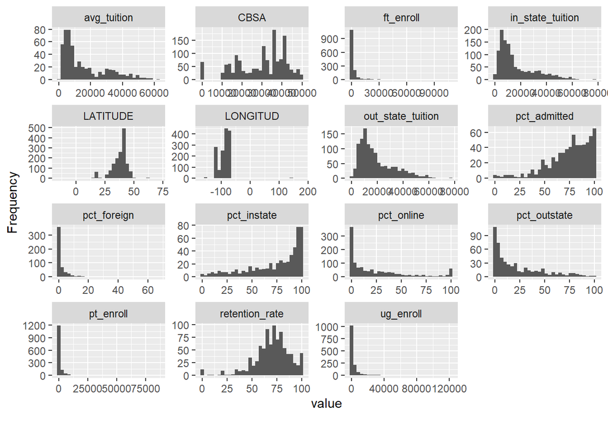

There doesn’t seem to be a unifying feature that links each school with missing ACT scores. Most schools are smaller, but there are some larger schools being left out. Accordingly, we can impute this missing data with the average value in our data, so we aren’t losing all these observations.

```r
school_data <- school_data %>%
  mutate(act_score = ifelse(is.na(act_score), mean(act_score, na.rm = TRUE), act_score))
```

Finally, k-means can only handle numeric data so we will remove any categorical features.

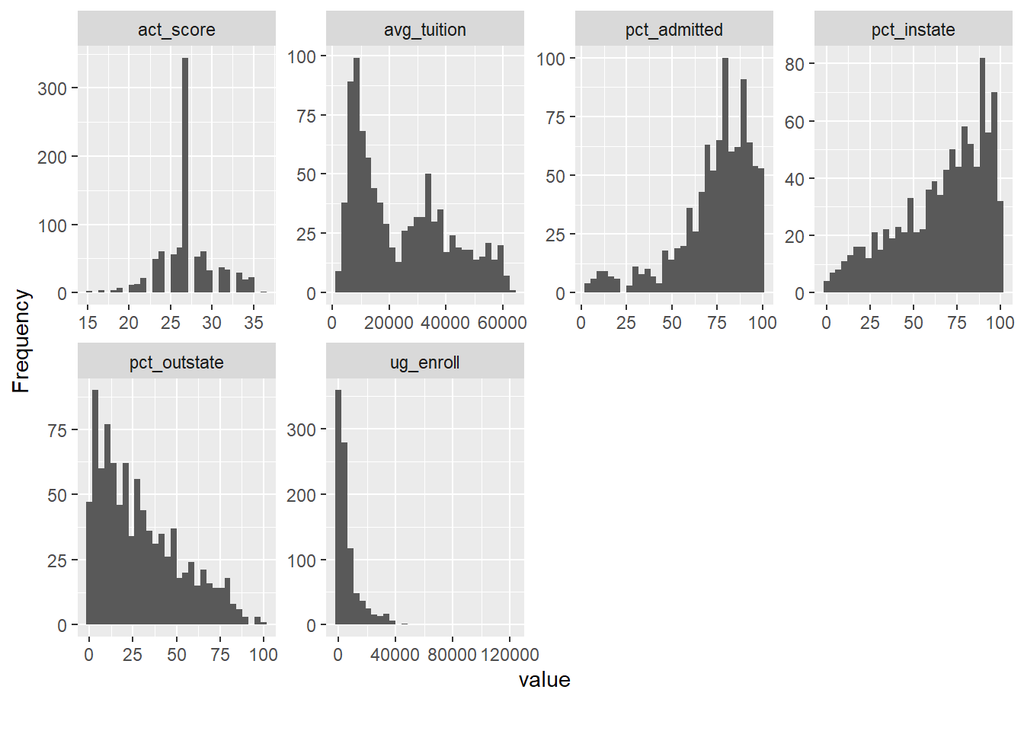

```r
school_full <- school_data

school_data <- school_data %>%
  filter(!is.na(act_score)) %>%
  drop_na()

modeled_data <- school_data %>%
  column_to_rownames(var = 'UNITID') %>%
  mutate(pct_admitted = ifelse(is.na(pct_admitted), imputed_admissions, pct_admitted)) %>%
  select(-ft_enroll, -pt_enroll, -pct_online, -pct_foreign, -retention_rate, -in_state_tuition, -out_state_tuition, -school,
         -CITY, -STABBR, -ZIP, -CBSA, -LATITUDE, -LONGITUD, -ADDR, -CONTROL) #These variables can explain the results of the analysis but themselves don't define 'selectivity' in our analysis

plot_histogram(modeled_data)
```

```r
summary(modeled_data)
```

```
##    act_score      pct_admitted      ug_enroll       pct_instate
##  Min.   :15.00   Min.   :  4.00   Min.   :    14   Min.   :  0.00
##  1st Qu.:26.00   1st Qu.: 66.00   1st Qu.:  1474   1st Qu.: 49.75
##  Median :27.01   Median : 79.00   Median :  2894   Median : 73.00
##  Mean   :27.14   Mean   : 73.76   Mean   :  6732   Mean   : 66.54
##  3rd Qu.:29.00   3rd Qu.: 89.00   3rd Qu.:  8013   3rd Qu.: 88.00
##  Max.   :36.00   Max.   :100.00   Max.   :121884   Max.   :100.00
##   pct_outstate     avg_tuition
##  Min.   :  0.00   Min.   : 1156
##  1st Qu.: 10.00   1st Qu.: 9395
##  Median : 24.00   Median :19129
##  Mean   : 29.43   Mean   :24253
##  3rd Qu.: 45.00   3rd Qu.:36263
##  Max.   :100.00   Max.   :62420
```

Now that we cleaned up the data, we can look at what fields will go into our k-means analysis.

```r
colnames(modeled_data)
```

```
## [1] "act_score"    "pct_admitted" "ug_enroll"    "pct_instate"  "pct_outstate"
## [6] "avg_tuition"
```